# Stat 202: Lecture 4 (covers pp. 48-61)

Nathan VanHoudnos  
10/1/2014

### Agenda

1. Lecture 3 comments
2. Homework comments
3. Checkpoint #3 results
4. Lecture 4 (covers pp. 48-61)

### $$ \text{Example of } Q \rightarrow C : \text{Target}$$

From [Wikipedia](http://en.wikipedia.org/wiki/Target_Corporation):

> Target is an American retailing company, founded in 1902 and headquartered in Minneapolis, Minnesota. It is the second-largest discount retailer in the United States,
- Their statistics team is lead by Andrew Pole
  - Keynote at 2010 Predictive Analytics World
  - [How Target Gets the Most out of Its Guest Data to Improve Marketing ROI](http://rmportal.performedia.com/rm/paw10/gallery_01#1373)
    - (examples start at 34:25)

### $$ \text{Example of } Q \rightarrow C : \text{Target}$$

- **Prediction of pregnancy status**
  - Having babies is a crazy time in your life.
  - [“As soon as we get them buying diapers from us, they’re going to start buying everything else too.“](http://www.nytimes.com/2012/02/19/magazine/shopping-habits.html?pagewanted=all&_r=0) – Pole
  - Pole built a model to predict if a guest was **pregnant**.
    - Increased their outreach to pregnant women by **30%**
    - Customizing a guests mailed coupons for pregnancy became **very** profitable!

### $$ \text{Example of } Q \rightarrow C : \text{Target}$$

However, one customer's experience from the [NYTimes](http://www.nytimes.com/2012/02/19/magazine/shopping-habits.html?pagewanted=all&_r=0):

> “My daughter got this in the mail!” he said. “She’s still in high school, and you’re sending her coupons for baby clothes and cribs? Are you trying to encourage her to get pregnant?”

### $$ \text{Example of } Q \rightarrow C : \text{Target}$$

But later…

> On the phone, though, the father was somewhat abashed. “I had a talk with my daughter,” he said. “It turns out there’s been some activities in my house I haven’t been completely aware of. She’s due in August. I owe you an apology.”

These are important issues!

- You can be right, but wrong to do it.
- With great **statistics** comes great responsibility.

### Companies pay well for these skills

From [Indeed.com/salary](http://www.indeed.com/salary)

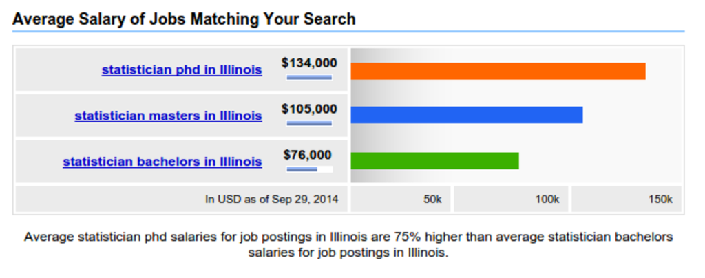

### Agenda

1. Lecture 3 comments
2. Homework comments
3. Checkpoint #3 results
4. Lecture 4 (covers pp. 48-61)

### Homework comments

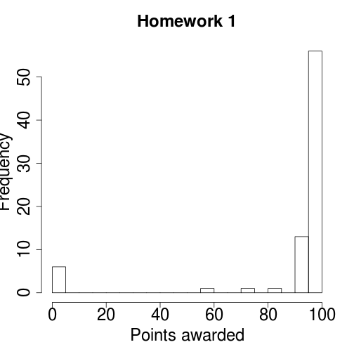

```r
mean(hw1.scores)
```

```
[1] 89.01
```

```r
median(hw1.scores)
```

```
[1] 98.67
```

Solutions on BlackBoard, under Documents

### Why do I teach you R?

From the [Revolution Analytics blog](http://blog.revolutionanalytics.com/2014/02/r-salary-surveys.html):

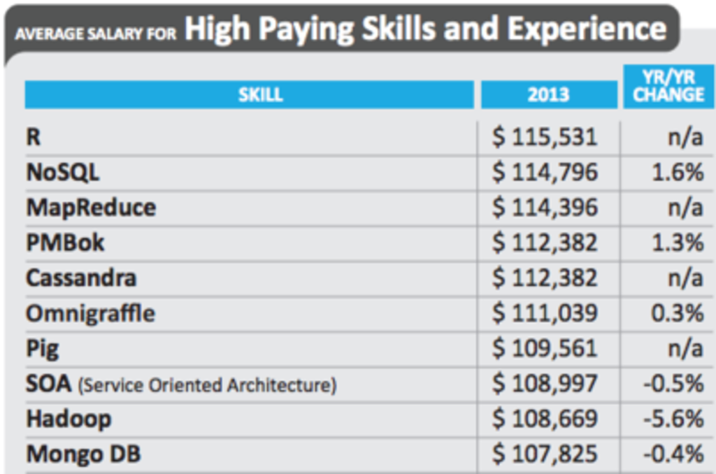

### Agenda

1. Lecture 3 comments
2. Homework comments
3. Checkpoint #3 results
4. Lecture 4 (covers pp. 48-61)

### Checkpoint #3 results

- Average score 88% correct
- About 1/3 of you missed the same question

### Question #5 Checkpoint #3

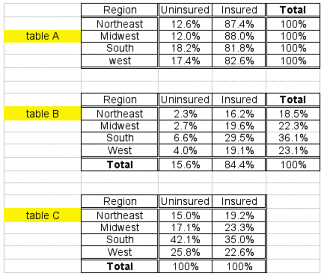

Which of the tables is the appropriate table of conditional percents to discover if the region where one lives affects whether or not one has health insurance?

### Agenda

1. Lecture 3 comments
2. Homework comments
3. Checkpoint #3 results
4. Lecture 4 (covers pp. 48-61)

### Strength of Linear Relationships

**Age v. Distance**

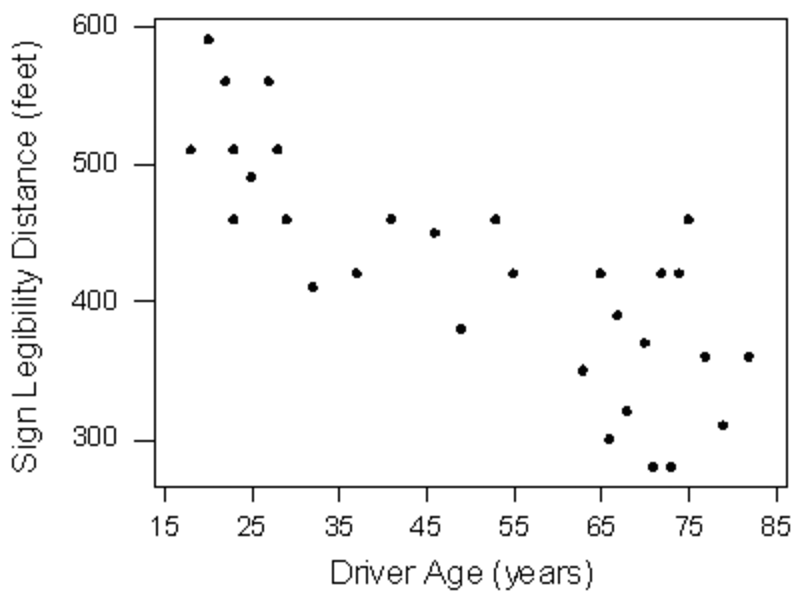

What is the effect of age on maximum legibility distance of a road sign?

Qualitative description:

- a negative, moderately strong linear relationship

**Quantitative measures:**

- correlation
- linear regression

### Correlation

We will:

- give a definition of the correlation \( r \)
- discuss the calculation of \( r \)
- explain how to interpret the value of \( r \), and
- talk about some of the properties of \( r \).

### Correlation: Defined

To quote (p. 49):

> The correlation coefficient \( r \) is a numerical measure that measures the strength and direction of a **linear relationship** between two **quantitative variables**.
- Can correlation measure of a curvelinear relationship? **No**
- Can two categorical variables be correlated with one another? **No**

### Correlation: Calculated

Let

- \( y_i \) be the \( i^{th} \) obs. of the response variable
- \( \bar{y} \) be the mean of the response variable
- \( S_y \) the standard deviation of the response variable

Similarly let \( x_i \), \( \bar{x} \), and \( S_x \) be defined for the explanatory variable. The correlation is:

\[ r = \frac{1}{n-1} \sum_{i=1}^n \left( \frac{x_i - \bar{x}}{S_x} \right) \left( \frac{y_i - \bar{y}}{S_y} \right) \]

### Correlation: Calculated

\[ r = \frac{1}{n-1} \sum_{i=1}^n \left( \frac{x_i - \bar{x}}{S_x} \right) \left( \frac{y_i - \bar{y}}{S_y} \right) \]

- This is more of a pain to calculate than the the standard deviation!
- **No one** calculates it by hand
- In this class, you
  - will learn the properties of \( r \)
  - how to interpret it, and
  - how to calculate it with R.

### Correlation: Properties

\[ r = \frac{1}{n-1} \sum_{i=1}^n \left( \frac{x_i - \bar{x}}{S_x} \right) \left( \frac{y_i - \bar{y}}{S_y} \right) \]

- A correlation between **age** in years and **distance** in feet has what units?
  - \( x_i - \bar{x} \) units of years
  - \( S_x \) units of years
  - \( \frac{x_i - \bar{x}}{S_x} := \frac{\text{years}}{\text{years}} := \text{unitless} \)
- **Changing the units (feet to inches) or (years to days) does not affect the correlation.**

### Correlation: Properties

\[ \begin{aligned} r & = \frac{1}{n-1} \sum_{i=1}^n \left( \frac{x_i - \bar{x}}{S_x} \right) \left( \frac{y_i - \bar{y}}{S_y} \right) \\ S_x & = \sqrt{ \frac{1}{n-1} \sum_{i=1}^n \left(x_i - \bar{x}\right)^2 } \end{aligned} \]

- You can prove that:
  - **\( -1 \le r \le 1 \)**
  - \( |r| = 1 \) if and only if \( y = a + xb \)
- \( r \) near zero implies a **weak linear** relationship

### Correlation: Examples

From [Wikipedia's page on correlation](http://en.wikipedia.org/wiki/Correlation_and_dependence):

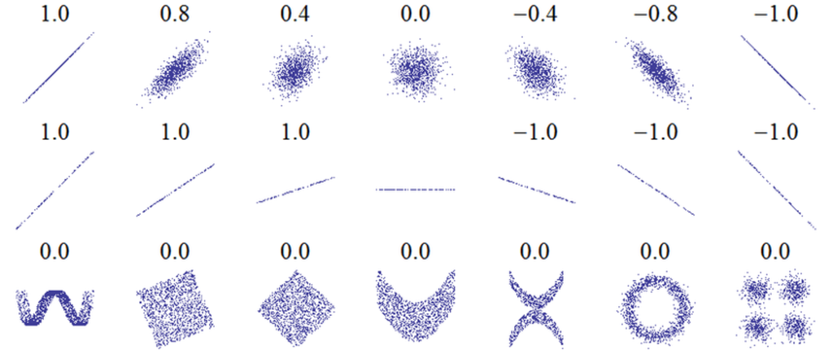

- **Warning:** Wikipedia defines correlation **more broadly** then Stat 202 does.

### Correlation: Outliers

Outliers can either

- **increase** the value of the correlation
- **decrease** the value of the correlation

If an outlier follows the (linear!) pattern it will…

- **increase** the value of the correlation

If an outlier breaks the (linear!) pattern it will…

- **decrease** the value of the correlation

See p. 51 for an interactive demo.

### Quantifying a linear relationship

- Correlation measures the **strength** of a linear relationship.
- **Linear regression** describes the specifics of a linear relationship
  - one of the most important statistical techniques
  - widely **used** and **abused**

### Linear regression concepts

Any line can be written as: \[ y = a + bx \] where

- \( x \) explanatory variable
- \( y \) response variable
- \( a \) is the intercept
- \( b \) is the slope
- (if this is unfamiliar see bottom of p. 53 for an algebra review)

How do we pick the **best line** for a given set of data?

### Age v. distance: n=6

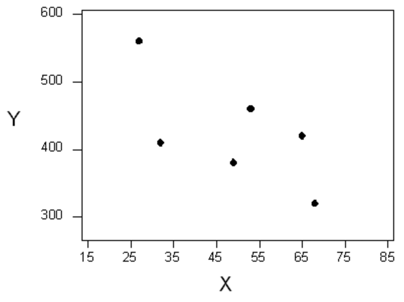

### Many possible lines

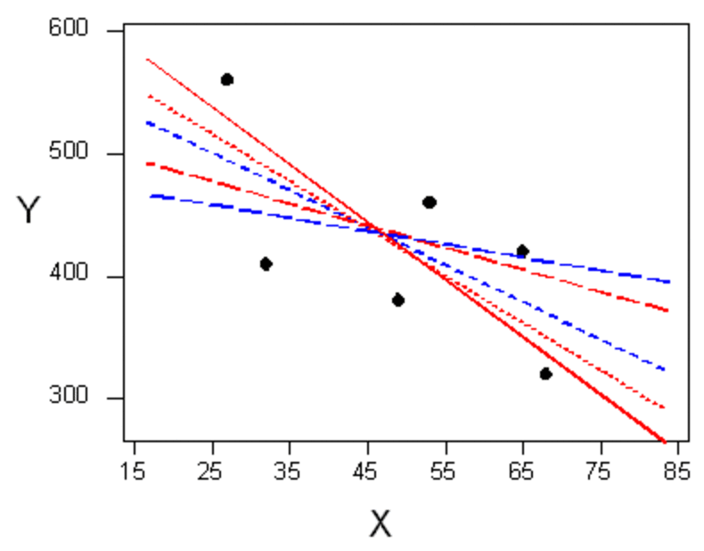

### Minimize vertical distance

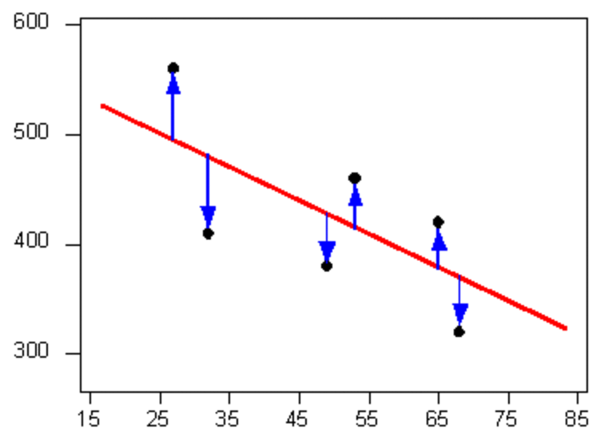

### By minimizing the area of the squares

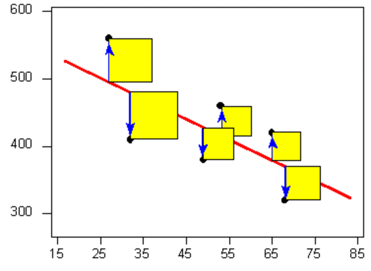

### Aside: Least-Squares regression

- [Gauss-Markov theorem](http://en.wikipedia.org/wiki/Gauss%E2%80%93Markov_theorem) states that least squares regression lines are the **best** possible regression lines under **a wide variety of conditions**
  - (proof requires post high school math)
- Stat 202 covers **two variable** \( Q \rightarrow Q \) regression
  - ignore the formulas for \( a \) and \( b \) on p. 54
- Stat 202 does not **not** cover multi-variable regression (**most common**)

### Least-Squares regression

Predicting gestation (in days) from the longevity (in years) of a given animal.

```r
head(animals)
```

```
        animal gestation longevity
1       baboon       187        20
2   bear-black       219        18
3 bear-grizzly       225        25
4   bear-polar       240        20
5       beaver       122         5
6      buffalo       278        15
```

### Gestation related to longevity?

```r
plot(
 gestation ~ longevity,
 xlab="Longevity (years)",
 ylab="Gestation (days)",
 data=animals)
```

[output not shown]

- read `~` as **by**
  - **gestation** by **longevity**
- read `xlab` as **x label**
- read `ylab` as **y label**
- read `data` as **data**

### Describe the plot

Direction, form and strength?

- positive linear moderate

Break or Keep pattern outliers?

- one **keep pattern**
- elephant

### Calculating Correlation

```r
cor( animals$gestation,
     animals$longevity )
```

```
0.6632
```

- read `cor` as **correlation**
- read `$` as **column**
  - animals **column** gestation
  - animals **column** longevity

### Least squares regression in R

```r
## Fit a least squares model and save
## it to the new variable 'animal.lm'
animal.lm <- lm(
  gestation ~ longevity, data=animals )

## Pull out the 'a' and 'b' values
coef(animal.lm)
```

```
(Intercept)   longevity
      21.71       13.13
```

\[ y = a + x b \]

- `(Intercept)` is \( a \)
- `longevity` is \( b \)

### Plotting the regression line

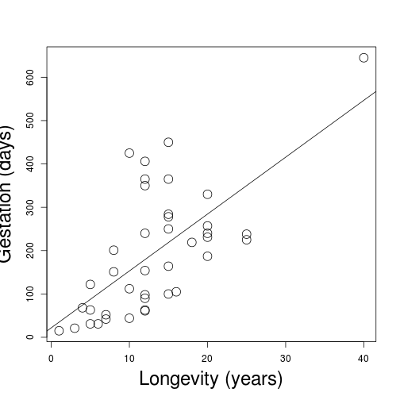

```r
## As before
plot(
 gestation ~ longevity,
 xlab="Longevity (years)",
 ylab="Gestation (days)",
 data=animals)

## Ad line
abline(animal.lm )
```

### Predicting w/ a regression line

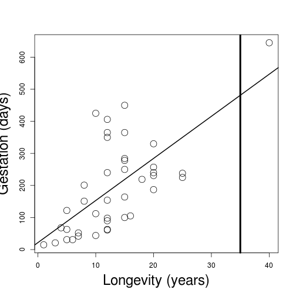

Gestation of an animal with 35 years longevity?

```r
coef( animal.lm )
```

```
(Intercept)   longevity
      21.71       13.13
```

\[ \begin{aligned} y & = a + b x \\ & = 21.71 + 13.13 \times 35 \\ & = 481.26 \end{aligned} \]

### Predicting w/ a regression line

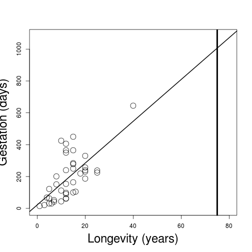

Is this **extrapolation** a good idea?

- **No** do not predict outside of your data!
- human gestation \( \approx \) 268 days

### Bars and churches

A simulated example

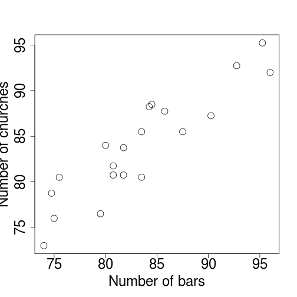

```
Correlation:  0.905
```

What is the relationship between the number of bars and the number of churches in a city?

- strong, positive, linear relationship
- no outliers

Do bars **cause** more churches to start?

### Bars and churches

Population v. churches

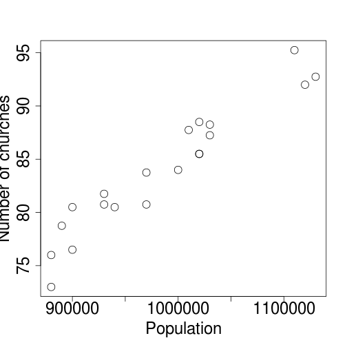

Population v. bars

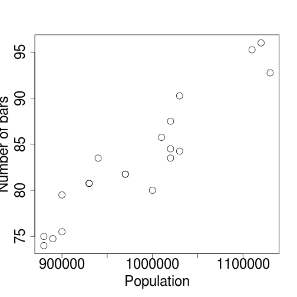

### Correlation and Causation

[figure not shown]

- http://xkcd.com/552/

More generally **association** does not imply **causation**.

### $$\text{Association for } C \rightarrow C $$

Are patients in Hospital A more likely to die than patients in Hospital B?

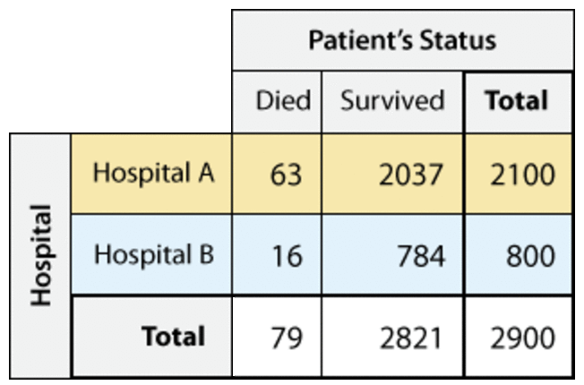

### $$\text{Association for } C \rightarrow C $$

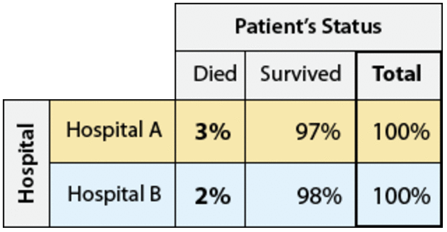

- Looks **bad** for Hospital A

### $$\text{Association for } C \rightarrow C $$

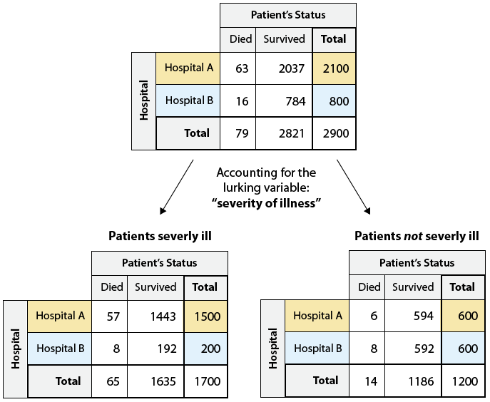

### $$\text{Association for } C \rightarrow C $$

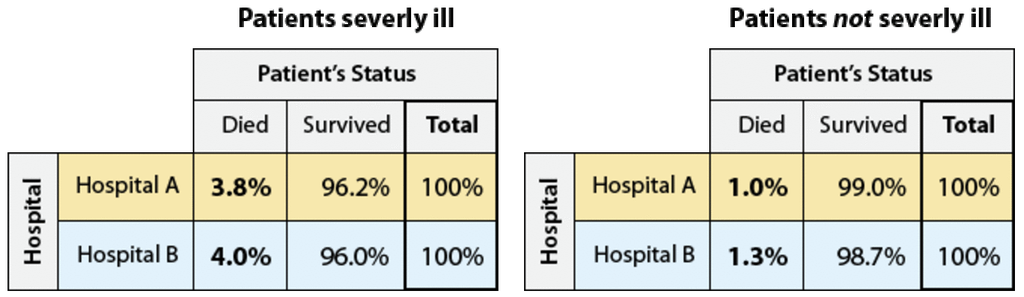

**Simpson's paradox**

- Ignoring illness severity suggested Hospital B was better
- In fact, Hospital A is **always** better
- a **lurking variable** reversed the association

### Causality Summary

**Association does not imply causation**

- High correlation does not imply causation
- Simpson's paradox can bite you on categorical data

All is not lost…

### Notes

- Checkpoint #4 covers Lectures 3 and 4
- see p. 62 for a review of Module 1